# Using R to calculate standard biodiversity indices

Let’s begin by setting up our workspace, which involves a few lines of code that clean the environment and turn on some packages.

```r
rm(list=ls()) #clears R's memory for a fresh start
library(tidyverse) #turns on a bunch of helpful packages
library(here) #turns on the here package for navigating directories
library(vegan) #turns on package for calculating diversity indices
library(betapart) #turns on package for beta diversity (needed for Jaccard)
library(rstatix) #turns on package with some matrix maniuplation functions
```

Now let’s pull in some data

```r
DF<-read.csv(here("Data", "MammalMatrix.csv"))
```

DF has the number of mammals of each species captured from 71 camera traps located around northern New York as part of my research.

Each row is an individual camera. The first column is junk, so let’s delete it.

```r
DF<-DF[,2:23]
```

Now the first three columns identify the camera, number of nights the camera was out, and the number of detections at the camera. The remaining 19 columns each represent a single mammal species. Numbers in each cell are the number of pictures of that species per 100 camera nights.

Let’s set aside the first three columns into a new dataframe for later use:

```r
DivIndices<-DF[,1:3]
```

And make a dataframe that just has the mammal species:

```r
Mammals<-DF[,4:22]
```

Now use the `vegan` package to calculate diversity indices.Save the results of each index as a new column in DivIndices

```r
#species richness
DivIndices$SR<-specnumber(Mammals)

#simpson's index
DivIndices$Simpson<-diversity(Mammals, index = "simpson")
DivIndices$InvSimpson<-diversity(Mammals, index = "invsimpson")

#shanon index
DivIndices$Shannon<-diversity(Mammals, index = "shannon")
View(DivIndices)
```

Now let’s go from wide to long format for DivIndices

```r
DivLong <- DivIndices %>% pivot_longer(cols = SR:Shannon, values_to = "Value")
```

Now let’s calculate some summary statistics

```r
MammalSum<-DivLong %>% group_by(name) %>% summarise(
    IndexN = length(Value),
    IndexAvg = mean(Value, na.rm = T),
    IndexSD = sd(Value, na.rm = T),
    IndexSEM = IndexSD/sqrt(IndexN),
    IndexMax = max(Value),
    IndexMin = min(Value),
    Quant10 = quantile(Value, probs = c(0.10)),
    Quant90 = quantile(Value, probs = c(0.90))
)
```

Now join data

```r
AllData<-full_join(DivLong, MammalSum, by = c("name"))
```

Now let’s make a plot

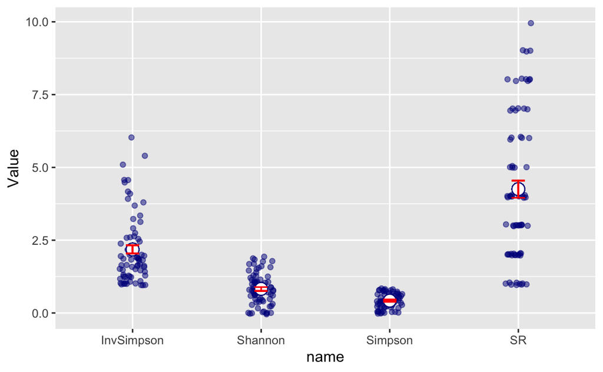

```r
ggplot(AllData, aes(name, Value))+
  geom_jitter(alpha = 0.5, color = "dark blue", width = 0.1, height = 0.05)+
  geom_point(aes(name, IndexAvg), shape = 21, size = 4, fill = "white",color = "dark blue")+
  geom_errorbar(aes(name,ymin = IndexAvg-IndexSEM, ymax = IndexAvg+IndexSEM),color = "red", width = 0.1)
```

```r
NA
```

Save the plot

```r
ggsave(here("Data", "Outputs", "MammalDiversity.png"))
```

Now calculate the Jaccard index for all pairs of plots

```r
#jaccard index
Jaccard<-betadiver(Mammals, "j") #j indicates to use the a/a+b+c formula
#result is of class 'distance' - convert to a matrix
Jaccard<-as.matrix(Jaccard)
```

Now use `betapart`package to get shared species between sites. The function requires a set of presence/absence rather than abundance data so we have to convert our DF dataset to that.

```r
#requires a dataset of presence/absence data so make that first
PresAb<-Mammals

PresAb[][PresAb[] != 0]<- 1 #assigns all values > 0 in cols 3:23 to 1
```

Now we can run the function to get the number of shared species between each pair of plots.

```r
Beta<-betapart.core(PresAb)#result is a list; we just need one part
Shared<-Beta$shared
```

Now it would be ideal if we could create a matrix with number of shared species (“a”) above the diagonal , species richness of each plot along the diagonal, and Jaccard index below the diagonal.

Let’s start by adding row and column names to our existing matrices to keep track of things.

```r
row.names(Jaccard)<-DivIndices$Cam_SD
colnames(Jaccard)<-DivIndices$Cam_SD

row.names(Shared)<-DivIndices$Cam_SD
colnames(Shared)<-DivIndices$Cam_SD
```

Since we want the # of shared species above the diagonal, let’s start with the shared matrix. Conveniently, it also has the number of species per plot as its diagonal.

So all we really need to do is put the Jaccard data below the diagonal.

```r
#using base r
Shared[lower.tri(Shared)]<-Jaccard[lower.tri(Jaccard, diag = FALSE)]
Shared<-round(Shared, digits = 3)
View(Shared)
#It worked!
```

Now write the matrix to a new location

```r
write.csv(Shared, here("Data", "Outputs","MammalDivComparison.csv"))
```

And write the summary of the diversity table out as well.

```r
write.csv(AllData, here("Data", "Outputs", "MammalDiversity.csv"))
```